# Nematode_Metabarcoding

Georgia Titcomb

April 25, 2019

# 1. Import data

```r
otus <- read.csv("with_names.csv")

tab3 <- read.table("OTU_log3.tab", header=T)
dim(tab3)
```

```
## [1] 329 694
```

```r
# This is the other OTU table based on different filtering thresholds
#tab35 <- read.table("OTU_log3.5.tab")
#dim(tab35)
```

# 2. Read summary

```r
# average reads per sample
summary(colSums(tab3[31:694]))
```

```
##    Min. 1st Qu.  Median    Mean 3rd Qu.    Max.
##     533    3270   10291   15561   23360   91421
```

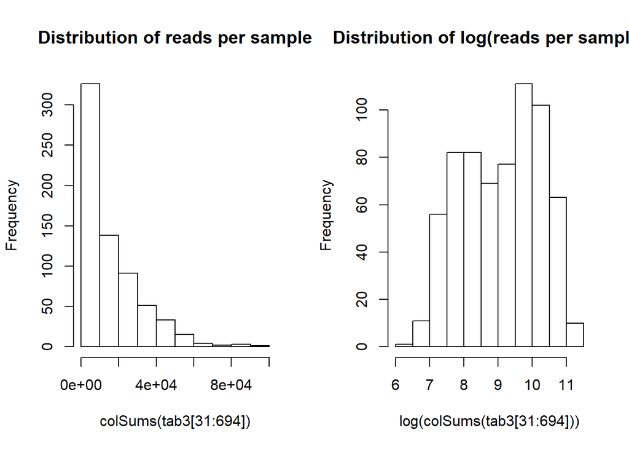

```r
par(mfrow=c(1,2))

hist(colSums(tab3[31:694]), main="Distribution of reads per sample")
hist(log(colSums(tab3[31:694])), main="Distribution of log(reads per sample)")
```

```r
min(colSums(tab3[31:694]))
```

```
## [1] 533
```

```r
max(colSums(tab3[31:694]))
```

```
## [1] 91421
```

The mean number of reads per sample is a little over 15,000, but with a median over ~10,000. There are quite a lot of OTUs per sample, so we need to standardize and filter out very rare reads that are likely to be errors.

# 3. Rarefaction and RRA

```r
rare_nem2 <- rrarefy(t(tab3[,31:694]), sample=533)
length(which(colSums(tab3[31:694])<1000)) # only one sample affected
```

```
## [1] 1
```

The next step is to calculate the relative read abundance (RRA) - defined in Pansu 2018 as the proportional read abundance of a given OTU within each sample.

```r
rare_nem2 <- as.data.frame(rare_nem2)

# Divide by the number of reads per sample to get the relative read abundance
rare_nem2_RRA <- rare_nem2 %>%
  mutate_at(vars(V1:V329), funs(./533))
```

Now create two datasets that filter out very low abundance reads (1% and 5%).

```r
rare_nem2_RRA_1pct <- rare_nem2_RRA %>%
  mutate_at(vars(V1:V329), funs(ifelse(.>0.01,.,0)))
rownames(rare_nem2_RRA_1pct) <- names(tab3)[31:694]
# recombine
rare_nem2_RRA_1pct <- cbind(tab3[,1:30],t(rare_nem2_RRA_1pct))
# remove empty OTU rows
rare_nem2_RRA_1pct <- rare_nem2_RRA_1pct[-which(rowSums(rare_nem2_RRA_1pct[,31:694])==0),]
dim(rare_nem2_RRA_1pct)
```

```
## [1] 102 694
```

```r
rare_nem2_RRA_5pct <- rare_nem2_RRA %>%
  mutate_at(vars(V1:V329), funs(ifelse(.>0.05,.,0)))
rownames(rare_nem2_RRA_5pct) <- names(tab3)[31:694]
rare_nem2_RRA_5pct <- cbind(tab3[,1:30],t(rare_nem2_RRA_5pct))

rare_nem2_RRA_5pct <- rare_nem2_RRA_5pct[-which(rowSums(rare_nem2_RRA_5pct[,31:694])==0),]
dim(rare_nem2_RRA_5pct)
```

```
## [1]  72 694
```

# 3. Comparison to Matt’s FECs

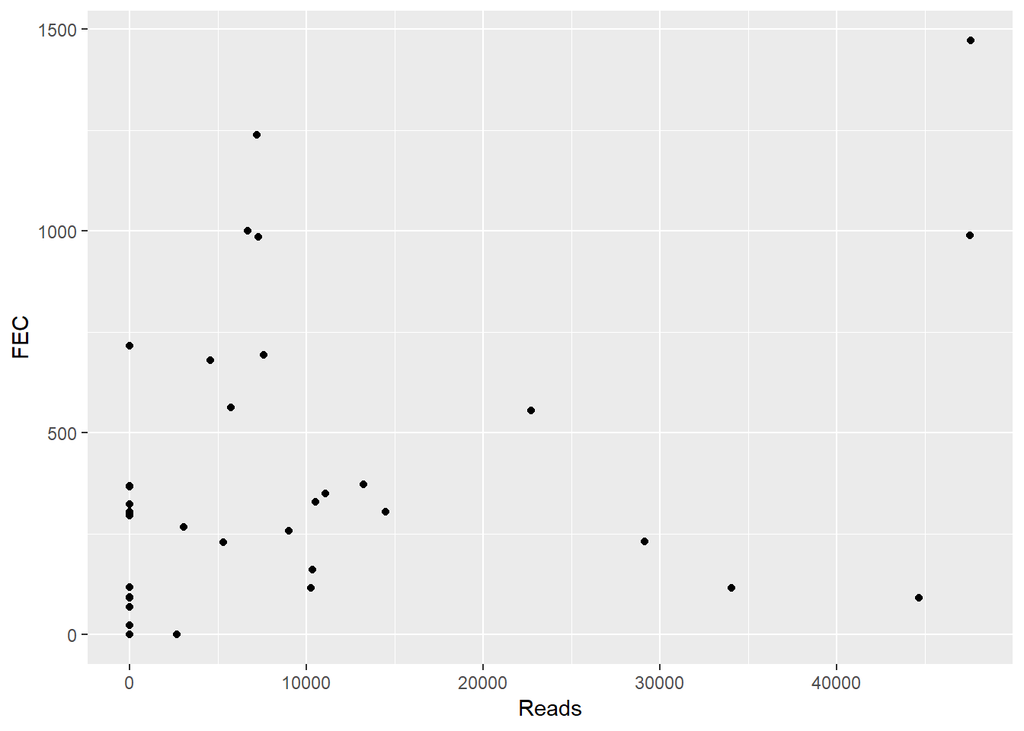

```r
# add metadata to RRA df

FECs <- read.csv("FEC_comparison.csv")

ggplot(FECs, aes(x=Reads, y=FEC))+
  geom_point()
```

Raw data shows one point where we have reads but FEC is 0. However, this is before filtering. Recombining the dataset using the 5 percent cutoff threshold:

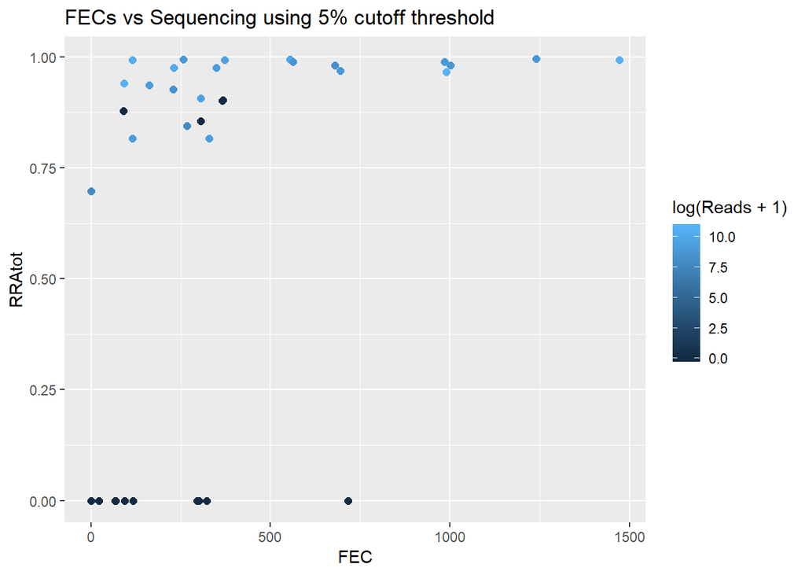

```r
FECs$sample2 <- paste("sample.",FECs$Sample, sep="")
names(rare_nem2_RRA_5pct)[31:694] <- str_pad(names(rare_nem2_RRA_5pct)[31:694],3,pad="0")

#rare_nem2_RRA_5pct[,(which(names(rare_nem2_RRA_5pct) %in% FECs$sample2))]
# Assuming that the ones that are False are 0 reads

b <- as.data.frame(colSums(rare_nem2_RRA_5pct[,(which(names(rare_nem2_RRA_5pct) %in% FECs$sample2))]))
b$sample2 <- rownames(b)
names(b) <- c("RRAtot","sample2")

joined_df <- left_join(FECs, b, by="sample2")

joined_df <- joined_df %>%
  mutate_at(vars(RRAtot), funs(ifelse(is.na(.)==T,0,.)))

ggplot(joined_df, aes(x=FEC, y=RRAtot))+
  geom_point(aes(color=log(Reads+1)), size=2)+
  ggtitle("FECs vs Sequencing using 5% cutoff threshold")
```

We get a similar result, with one sample having reads and no FEC count. However, it is notatble that the RRAtotal is lower than the rest, indicating a lot of low quality reads that got filtered out. I’m not sure exactly what to do with this sample.

Using the 1% threshold:

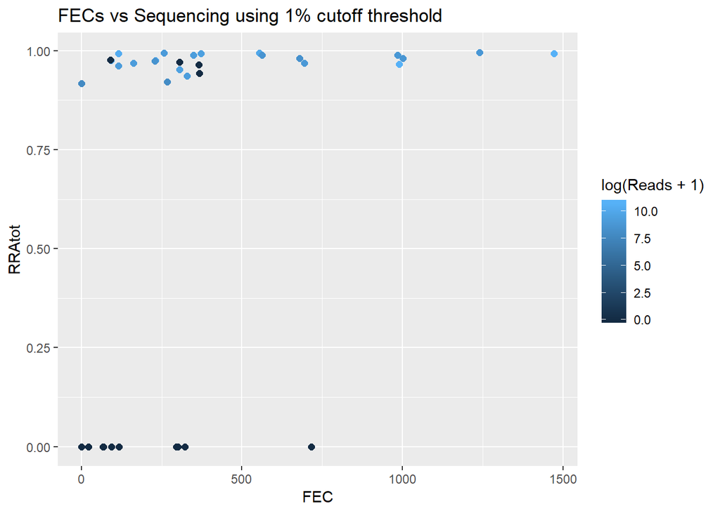

```r
FECs$sample2 <- paste("sample.",FECs$Sample, sep="")
names(rare_nem2_RRA_1pct)[31:694] <- str_pad(names(rare_nem2_RRA_1pct)[31:694],3,pad="0")

#rare_nem2_RRA_5pct[,(which(names(rare_nem2_RRA_5pct) %in% FECs$sample2))]
# Assuming that the ones that are False are 0 reads

b <- as.data.frame(colSums(rare_nem2_RRA_1pct[,(which(names(rare_nem2_RRA_1pct) %in% FECs$sample2))]))
b$sample2 <- rownames(b)
names(b) <- c("RRAtot","sample2")

joined_df <- left_join(FECs, b, by="sample2")

joined_df <- joined_df %>%
  mutate_at(vars(RRAtot), funs(ifelse(is.na(.)==T,0,.)))

ggplot(joined_df, aes(x=FEC, y=RRAtot))+
  geom_point(aes(color=log(Reads+1)), size=2)+
  ggtitle("FECs vs Sequencing using 1% cutoff threshold")
```

## OTU richness within sample

Given these results, we can now look at OTU richness per sample per species and location.

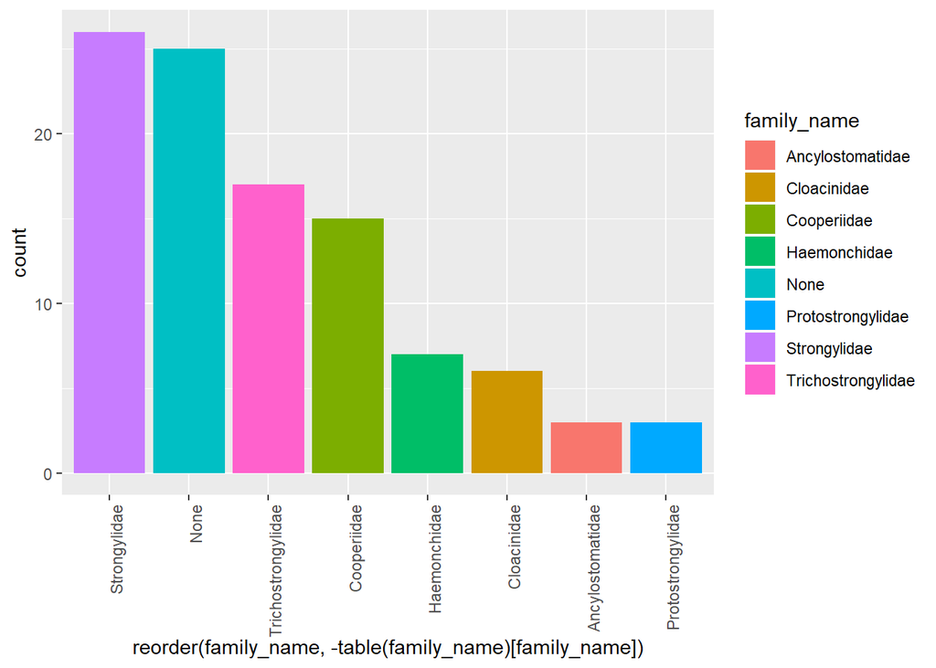

```r
# using the 1% threshold:
ggplot(rare_nem2_RRA_1pct, aes(x=reorder(family_name, -table(family_name)[family_name])))+
  geom_bar(aes(fill=family_name))+
  theme(axis.text.x=element_text(angle=90, hjust=1))
```

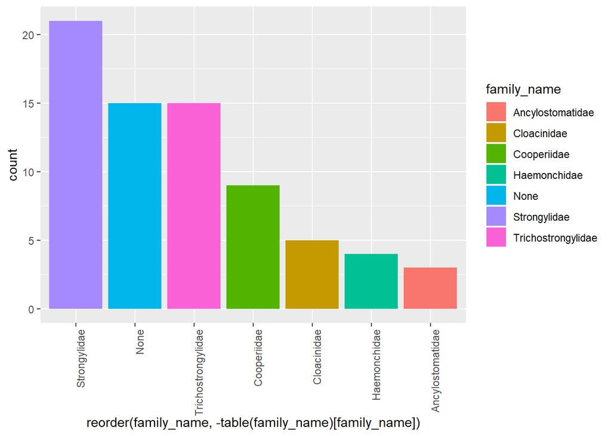

```r
# and 5%
ggplot(rare_nem2_RRA_5pct, aes(x=reorder(family_name, -table(family_name)[family_name])))+
  geom_bar(aes(fill=family_name))+
  theme(axis.text.x=element_text(angle=90, hjust=1))
```